# Practical Machine Learning Project - Human Activity Recognition Report

Deviprasad Pandey

22 April 2018

## Background

Using devices such as Jawbone Up, Nike FuelBand, and Fitbit it is now possible to collect a large amount of data about personal activity relatively inexpensively. These type of devices are part of the quantified self movement – a group of enthusiasts who take measurements about themselves regularly to improve their health, to find patterns in their behavior, or because they are tech geeks. One thing that people regularly do is quantify how much of a particular activity they do, but they rarely quantify how well they do it. In this project, your goal will be to use data from accelerometers on the belt, forearm, arm, and dumbell of 6 participants. They were asked to perform barbell lifts correctly and incorrectly in 5 different ways. More information is available from the website here: http://web.archive.org/web/20161224072740/http:/groupware.les.inf.puc-rio.br/har (see the section on the Weight Lifting Exercise Dataset).

## Data

The training data for this project are available here:

https://d396qusza40orc.cloudfront.net/predmachlearn/pml-training.csv

The test data are available here:

https://d396qusza40orc.cloudfront.net/predmachlearn/pml-testing.csv

The data for this project come from this source: http://web.archive.org/web/20161224072740/http:/groupware.les.inf.puc-rio.br/har. If you use the document you create for this class for any purpose please cite them as they have been very generous in allowing their data to be used for this kind of assignment.

## The Goal

The goal of your project is to predict the manner in which they did the exercise. This is the “classe” variable in the training set. You may use any of the other variables to predict with. You should create a report describing how you built your model, how you used cross validation, what you think the expected out of sample error is, and why you made the choices you did. You will also use your prediction model to predict 20 different test cases.

## Setup

Below libraries were used in this project. One would need to install and load them in their working enviorment

```r
library(rattle)
library(caret)
```

```r
library(rpart)
library(rpart.plot)
library(corrplot)
library(randomForest)
library(RColorBrewer)
```

## Downloading Data

Download the data files provided. Check if they are present in the data folder and if not download them from the url provided. We have been provided by 2 urls, one for training data and other for test data.

```r
trainUrl <-"https://d396qusza40orc.cloudfront.net/predmachlearn/pml-training.csv"
testUrl <- "https://d396qusza40orc.cloudfront.net/predmachlearn/pml-testing.csv"

trainFile <- "./data/pml-training.csv"
testFile  <- "./data/pml-testing.csv"

if (!file.exists("./data")) {
dir.create("./data")
}

if (!file.exists(trainFile)) {
download.file(trainUrl, destfile = trainFile)
}

if (!file.exists(testFile)) {
download.file(testUrl, destfile = testFile)
}

rm(trainUrl)
rm(testUrl)
```

## Loading the data

Once the data is downloaded from the data source, we can read the two csv files into two data frames. When loaded the data first time, noticed that it contains columns with values like “#DIV/0!”. Hence passing such values to be treated as NA when loading the data.

```r
train <- read.csv(trainFile,na.strings = c("NA","#DIV/0!", ""))
test <- read.csv(testFile,na.strings = c("NA","#DIV/0!", ""))

dim(train)
```

```
## [1] 19622   160
```

```r
dim(test)
```

```
## [1]  20 160
```

By looking at the structure of the train data we see that, the training data set contains 19622 observations and 160 variables, while the testing data set contains 20 observations and 160 variables. The `classe` variable in the training set is the outcome to predict.

## Cleaning Data

```r
train <- train[,colSums(is.na(train))==0]
test <- test[,colSums(is.na(test))==0]

##Removing few unwanted variables

regex <- grepl("^X|timestamp|user_name", names(train))

train <- train[, !regex]
test <- test[, !regex]
dim(train)
```

```
## [1] 19622    55
```

```r
dim(test)
```

```
## [1] 20 55
```

```r
str(train)
```

```
## 'data.frame':    19622 obs. of  55 variables:
##  $ new_window          : Factor w/ 2 levels "no","yes": 1 1 1 1 1 1 1 1 1 1 ...
##  $ num_window          : int  11 11 11 12 12 12 12 12 12 12 ...
##  $ roll_belt           : num  1.41 1.41 1.42 1.48 1.48 1.45 1.42 1.42 1.43 1.45 ...
##  $ pitch_belt          : num  8.07 8.07 8.07 8.05 8.07 8.06 8.09 8.13 8.16 8.17 ...
##  $ yaw_belt            : num  -94.4 -94.4 -94.4 -94.4 -94.4 -94.4 -94.4 -94.4 -94.4 -94.4 ...
##  $ total_accel_belt    : int  3 3 3 3 3 3 3 3 3 3 ...
##  $ gyros_belt_x        : num  0 0.02 0 0.02 0.02 0.02 0.02 0.02 0.02 0.03 ...
##  $ gyros_belt_y        : num  0 0 0 0 0.02 0 0 0 0 0 ...
##  $ gyros_belt_z        : num  -0.02 -0.02 -0.02 -0.03 -0.02 -0.02 -0.02 -0.02 -0.02 0 ...
##  $ accel_belt_x        : int  -21 -22 -20 -22 -21 -21 -22 -22 -20 -21 ...
##  $ accel_belt_y        : int  4 4 5 3 2 4 3 4 2 4 ...
##  $ accel_belt_z        : int  22 22 23 21 24 21 21 21 24 22 ...
##  $ magnet_belt_x       : int  -3 -7 -2 -6 -6 0 -4 -2 1 -3 ...
##  $ magnet_belt_y       : int  599 608 600 604 600 603 599 603 602 609 ...
```

[output cut: 41 more lines]

After the cleanup we now have cleaned training data set which contains 19622 observations and 55 variables, while the test data set contains 20 observations and 55 variables.

## Split Training Set into train and validation

Now we will split cleaned training set into a two parts. One to be used for training (70%) the model and second to be used for validation (30%). We will use the validation data set to conduct cross validation.

```r
set.seed(1200) # For reproducibile purpose
mysplit <- createDataPartition(train$classe, p = 0.70, list = FALSE)
training <- train[mysplit, ]
validation <- train[-mysplit, ]
```

Dataset now consists of 55 variables with the observations divided as following:  
1. Training Data: 13737 observations.  
2. Validation Data: 5885 observations.  
3. Testing Data: 20 observations.

## Exploratory analysis

The variable `classe` contains 5 levels. The plot of the outcome variable shows the frequency of each levels in the Training data.

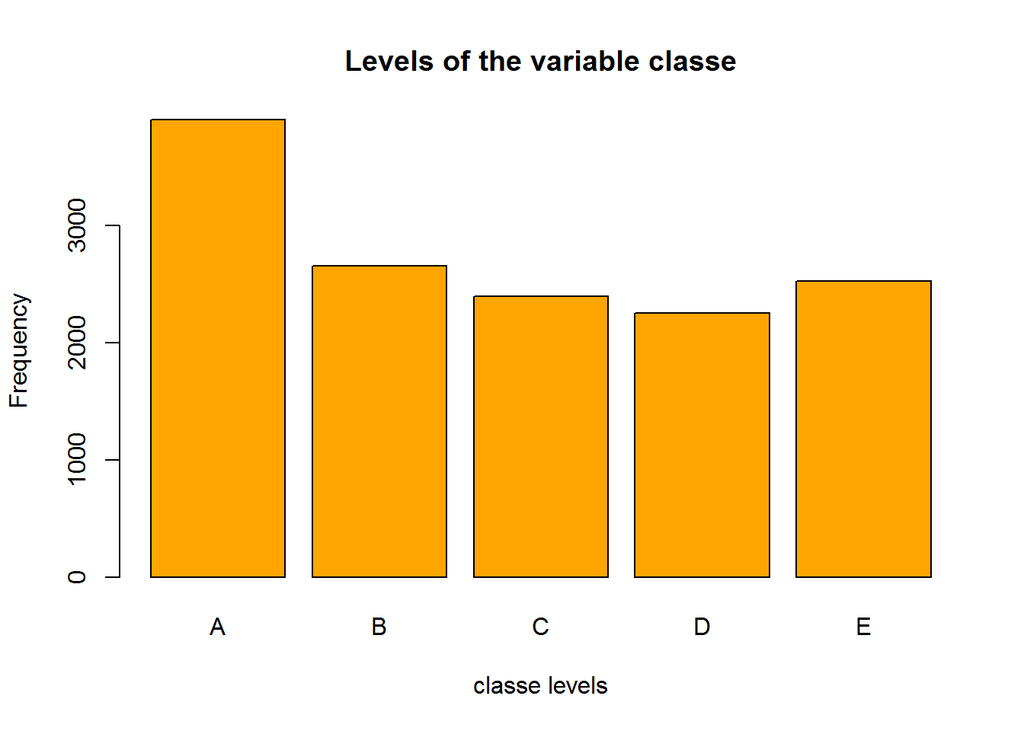

```r
plot(training$classe, col="orange", main="Levels of the variable classe", xlab="classe levels", ylab="Frequency")
```

The plot above shows that Level A is the most frequent classe. D appears to be the least frequent one.

## Predictive Models

In this section a decision tree and random forest will be applied to the data.

### Decision Tree

Fit a predictive model for activity recognition using **Decision Tree** algorithm.

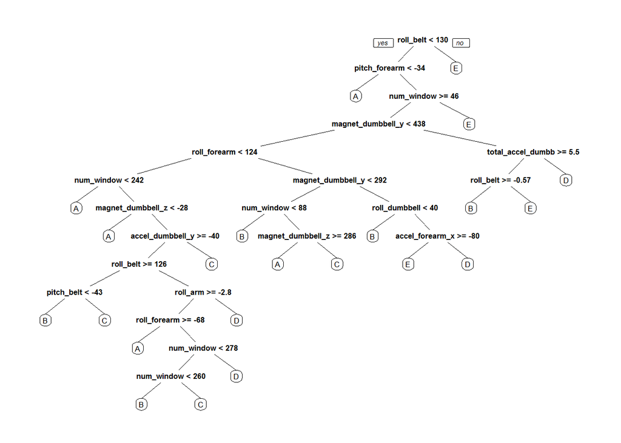

```r
modelTree <- rpart(classe ~ ., data = training, method = "class")
prp(modelTree)
```

Now, we estimate the performance of the model on the **validation** data set.

```r
predictTree <- predict(modelTree, validation, type = "class")

confusionMatrix(validation$classe, predictTree)
```

```
## Confusion Matrix and Statistics
##
##           Reference
## Prediction    A    B    C    D    E
##          A 1529   54    9   65   17
##          B  271  647   62   94   65
##          C   21   36  836   75   58
##          D   81   19  120  651   93
##          E   46   20   66  138  812
##
## Overall Statistics
##
##                Accuracy : 0.7604
##                  95% CI : (0.7493, 0.7713)
##     No Information Rate : 0.331
##     P-Value [Acc > NIR] : < 2.2e-16
##
##                   Kappa : 0.6955
##  Mcnemar's Test P-Value : < 2.2e-16
##
## Statistics by Class:
##
##                      Class: A Class: B Class: C Class: D Class: E
## Sensitivity            0.7849   0.8338   0.7649   0.6364   0.7770
## Specificity            0.9632   0.9037   0.9604   0.9356   0.9442
## Pos Pred Value         0.9134   0.5680   0.8148   0.6753   0.7505
## Neg Pred Value         0.9005   0.9728   0.9471   0.9244   0.9515
## Prevalence             0.3310   0.1319   0.1857   0.1738   0.1776
## Detection Rate         0.2598   0.1099   0.1421   0.1106   0.1380
## Detection Prevalence   0.2845   0.1935   0.1743   0.1638   0.1839
## Balanced Accuracy      0.8740   0.8687   0.8626   0.7860   0.8606
```

```r
accuracy <- postResample(predictTree, validation$classe)
ose <- 1 - as.numeric(confusionMatrix(validation$classe, predictTree)$overall[1])
```

The Estimated Accuracy of the Decision Tree model Model is 76.0407816% and the Estimated Out-of-Sample Error is 23.9592184%.

### Random Forest

We fit a predictive model for activity recognition using **Random Forest** algorithm because it automatically selects important variables and is robust to correlated covariates & outliers in general.

We will use **5-fold cross validation** when applying the algorithm.

```r
modelRF <- train(classe ~ ., data = training, method = "rf", trControl = trainControl(method = "cv", 5), ntree = 250)
modelRF
```

```
## Random Forest
##
## 13737 samples
##    54 predictor
##     5 classes: 'A', 'B', 'C', 'D', 'E'
##
## No pre-processing
## Resampling: Cross-Validated (5 fold)
## Summary of sample sizes: 10989, 10989, 10990, 10991, 10989
## Resampling results across tuning parameters:
##
##   mtry  Accuracy   Kappa
##    2    0.9937393  0.9920799
##   28    0.9970880  0.9963165
##   54    0.9954858  0.9942894
##
## Accuracy was used to select the optimal model using the largest value.
## The final value used for the model was mtry = 28.
```

Now, we estimate the performance of the model on the **validation** data set.

```r
predictRF <- predict(modelRF, validation)

confusionMatrix(validation$classe, predictRF)
```

```
## Confusion Matrix and Statistics
##
##           Reference
## Prediction    A    B    C    D    E
##          A 1672    1    0    0    1
##          B    1 1134    4    0    0
##          C    0    3 1023    0    0
##          D    0    0    1  963    0
##          E    0    0    0    0 1082
##
## Overall Statistics
##
##                Accuracy : 0.9981
##                  95% CI : (0.9967, 0.9991)
##     No Information Rate : 0.2843
##     P-Value [Acc > NIR] : < 2.2e-16
##
##                   Kappa : 0.9976
##  Mcnemar's Test P-Value : NA
##
## Statistics by Class:
##
##                      Class: A Class: B Class: C Class: D Class: E
## Sensitivity            0.9994   0.9965   0.9951   1.0000   0.9991
## Specificity            0.9995   0.9989   0.9994   0.9998   1.0000
## Pos Pred Value         0.9988   0.9956   0.9971   0.9990   1.0000
## Neg Pred Value         0.9998   0.9992   0.9990   1.0000   0.9998
## Prevalence             0.2843   0.1934   0.1747   0.1636   0.1840
## Detection Rate         0.2841   0.1927   0.1738   0.1636   0.1839
## Detection Prevalence   0.2845   0.1935   0.1743   0.1638   0.1839
## Balanced Accuracy      0.9995   0.9977   0.9973   0.9999   0.9995
```

```r
accuracyRF <- postResample(predictRF, validation$classe)
oseRF <- 1 - as.numeric(confusionMatrix(validation$classe, predictRF)$overall[1])
```

The Estimated Accuracy of the Random Forest Model is 99.8130841% and the Estimated Out-of-Sample Error is 0.1869159%.  
Random Forests yielded better Results, as expected. The Random Forest model is choosen.

## Predicting The Manner of Exercise for Test Data Set

Now, we apply the **Random Forest** model to the original testing data set downloaded from the data source. We remove the problem_id column first.

```r
rm(accuracy)
rm(ose)
preTest <- predict(modelRF, test[, -length(names(test))])
```

## Generating Files to submit as answers for the Assignment

Function to generate files with predictions to submit for assignment.

```r
pml_write_files = function(x){
  n = length(x)
  for(i in 1:n){
    filename = paste0("./Assignment_Solutions/problem_id_",i,".txt")
    write.table(x[i], file = filename, quote = FALSE, row.names = FALSE, col.names = FALSE)
  }
}
```

Generating the Files.

```r
pml_write_files(predict(modelRF, test[, -length(names(test))]))
```